# S&P500 Concentration

Riccardo Santarossa

2026-10-23

```r
library(tidyverse)
library(tidyquant)
library(ineq)
library(ggplot2)
```

```r
#raccolta dati
spData = tq_index("S&P500")
write_csv(spData, "data/sp500Data.csv")
```

**Punto 1**

Per comprendere come sono distribuiti e quanto sono variegati i pesi delle singole aziende all’interno dell’indice, si calcolano prima le principali statistiche descrittive, quindi media, mediana, deviazione standard, massimo e minimo. Successivamente, con l’uso di un istogramma, si vuole visualizzare la distribuzione delle aziende, quindi comprendere quante aziende hanno un peso significativo, e quante invece un peso molto contenuto.

```r
#dataframe di partenza
spDF = read_csv("data/sp500Data.csv")

#aziende e relativi pesi
spWeights= spDF |>
  select(company, weight, shares_held) |>
  arrange(desc(weight))

#statistiche sui pesi dal dataframe
stats = spDF |> summarise(mean = mean(weight), median = median(weight), max = max(weight), min = min(weight), stdDev = sd(weight))
stats
```

```
## # A tibble: 1 × 5
##      mean   median    max          min  stdDev
##     <dbl>    <dbl>  <dbl>        <dbl>   <dbl>
## 1 0.00198 0.000678 0.0777 0.0000000300 0.00630
```

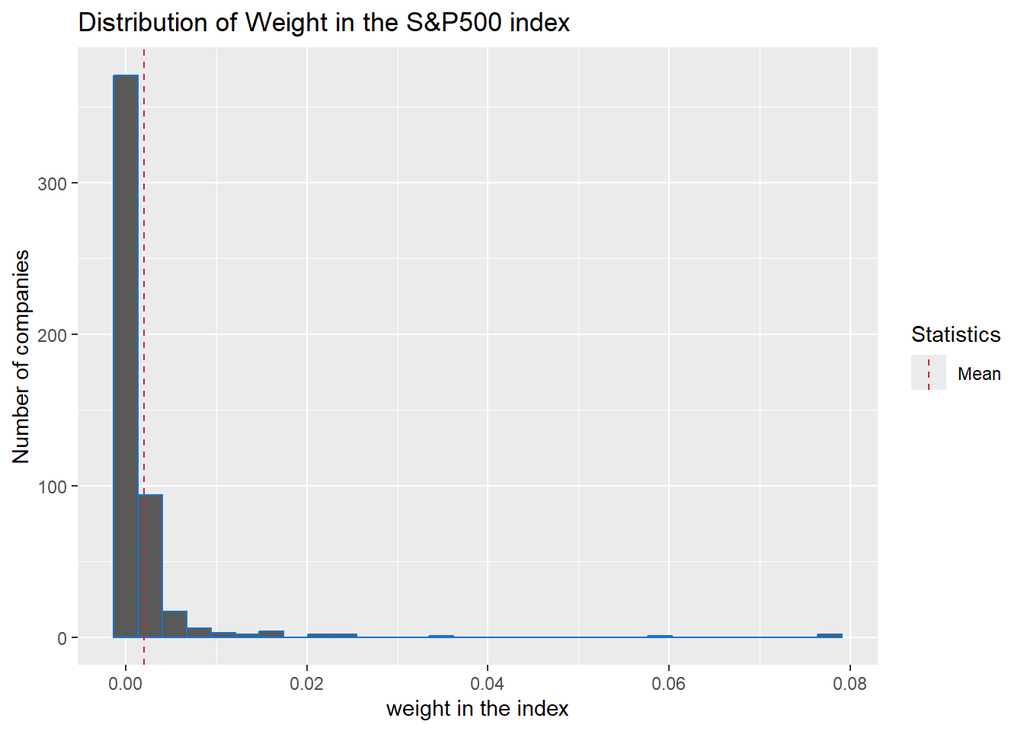

```r
#istogramma con pesi e aziende
ggplot(spDF, aes(x = weight)) +
  geom_histogram(colour = "#1874CD") +
  geom_vline(aes(xintercept = stats$mean, colour = "Mean"), linetype = "dashed") +
  scale_colour_manual(name = "Statistics", values = c("Mean" = "#CD2626")) +
  labs(title = "Distribution of Weight in the S&P500 index", x = "weight in the index", y = "Number of companies")
```

Dall’istogramma si può notare come la maggioranza delle aziende contenute nell’indice abbiano un peso, in termini di percentuale sul totale, molto contenuto. La *media* infatti, calcolata in precedenza, è vicina allo zero, ciò indica che il peso medio in termini percentuali è dello 0.2%. Sono presenti comunque aziende con un valore percentuale significativamente più alto, il massimo infatti si attesta a 7.77%.

**Punto 2**

Si vuole capire quanto dell’indice sia detenuto dalle principali aziende coinvolte: prima si calcola il coinvolgimento di ogni azienda in termini di peso (in percentuale), e succesivamente in termini di azioni detenute sul totale delle azioni dell’indice.

```r
#percentuale
top10CompaniesWeights = spWeights |>
  select(weight) |>
  head(10) |>
  sum()
top10CompaniesPercentage = top10CompaniesWeights * 100

top10CompaniesPercentage
```

```
## [1] 37.36399
```

```r
#sul numero di azioni
totalShares = spWeights |> select(shares_held) |> sum()
sharesTop10 = spWeights |>
  select(shares_held) |>
  head(10) |>
  sum()
top10CompaniesShares = sharesTop10 / totalShares * 100

top10CompaniesShares
```

```
## [1] 19.1083
```

**Punti 3 e 4**

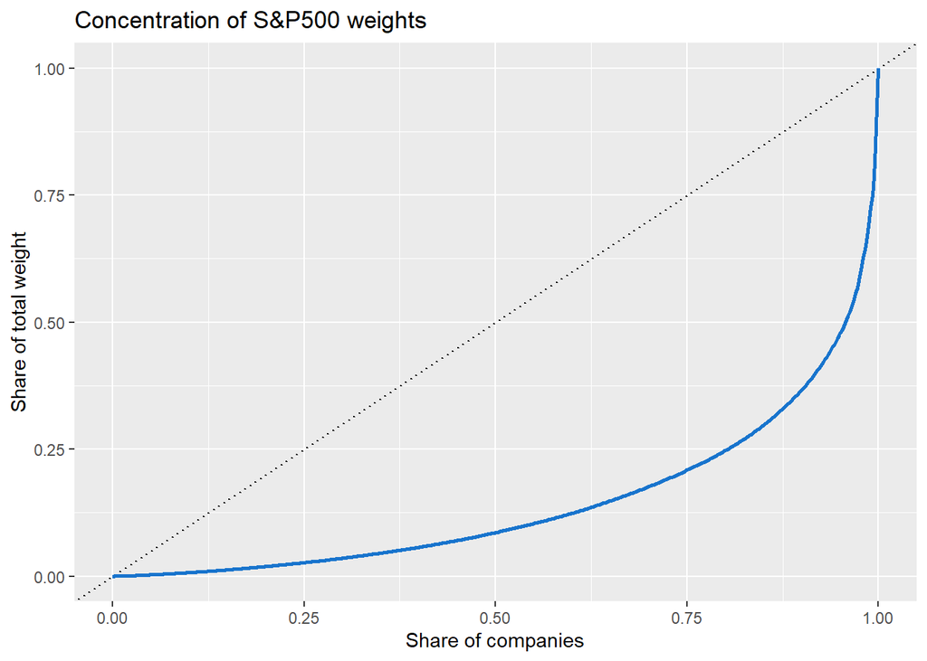

```r
#calcolo del GiniIndex e rappresentazione della curva di Lorentz
LCData = Lc(spWeights$weight)
dfLorentz = data.frame(p = LCData$p, L = LCData$L)

#plot della Lorentz Curve
ggplot(dfLorentz, aes(x = p, y = L)) +
  geom_abline(slope = 1, intercept = 0, linetype = "dotted") +
  geom_line(linewidth = 1, colour = "#1874CD") +
  labs(title = "Concentration of S&P500 weights", x = "Share of companies", y = "Share of total weight")
```

Dal grafico della curva di Lorentz si osserva come il 50% delle aziende detengano meno del 25% del peso totale: ciò dimostra come la maggioranza del peso dell’indice sia dettata da un numero ristretto di aziende, come già mostrato al punto 2.

Calcolo del Gini coefficient:

```r
#calcolo del Gini coefficient
giniCoeff = Gini(spWeights$weight)
giniCoeff
```

```
## [1] 0.7116953
```

Il valore del Gini Coefficient conferma ulteriormente quanto detto finora: il suo valore di 0.71 dimostra come ci sia un’inequalità elevata nella distribuzione dei pesi delle aziende.